# Lifelines Datadashboard

### Introduction

**Data:**

The data used is a synthetic dataset, this means that the values are not the exact same as the ones that were measured but a statisticallcly representative dataset. This is done to enhance privacy of the participants. The methods used for this are: differential privacy and k-anonymity. This way the relationsships between the variables are conserverd. Source: https://www.lifelines-biobank.com/synthetic-data-a-new-step-forward-in-data-availability-at-lifelines-in-collaboration-with-syntho

**Libraries** The following libraries are used:

```r
library(tidyverse)
```

```r
lifelines_df <- read.csv(file = "/home/floris/Documenten/Data_set/Lifelines/2024/Dataset/Lifelines Public Health dataset - 2024.csv", header = TRUE)
```

### Making factors

Making factors for the schale data using the following variables:

NEIGHBOURHOOD1_T2 ‘Satisfaction with the current living environment (scored on a scale of 1 to 10) at second assessment (T2)’

NEIGHBOURHOOD2_T2 ’Characteristics of neighbourhood (ranging from a very green neighbourhood (1) to a neighbourhood with practically no greenery (5)

NEIGHBOURHOOD3_T2 ’Unpleasantness to live in this neighbourhood (ranging from completely disagree (1) to completely agree (5)

NEIGHBOURHOOD4_T2 ’If possible, would like to move from this neighbourhood (ranging from completely disagree (1) to completely agree (5))

NEIGHBOURHOOD5_T2 ’Attached to this neighbourhood (ranging from completely disagree (1) to completely agree (5))

NEIGHBOURHOOD6_T2 ’Feels at home in this neighbourhood (ranging from completely disagree (1) to completely agree (5))

The following factors are about socioeonomically determined variables:

```r
lifelines_df$neighborhood_satisfaction <- lifelines_df$NEIGHBOURHOOD1_T2 %>%  factor(levels = c(1:10), labels = c(1:10))

lifelines_df$neighborhood_characteristics <- lifelines_df$NEIGHBOURHOOD2_T2 %>%  factor(levels = c(1:5), labels = c(1:5))

lifelines_df$neighborhood_unpleasantness <- lifelines_df$NEIGHBOURHOOD3_T2 %>%  factor(levels = c(1:5), labels = c("Completely agree", "Agree", "Neutral", "Disagree", "Completely disagree"))

lifelines_df$neighborhood_moving_away <- lifelines_df$NEIGHBOURHOOD4_T2 %>%  factor(levels = c(1:5), labels = c("Completely agree", "Agree", "Neutral", "Disagree", "Completely disagree"))

lifelines_df$neighborhood_attached <- lifelines_df$NEIGHBOURHOOD5_T2 %>%  factor(levels = c(1:5), labels = c("Completely agree", "Agree", "Neutral", "Disagree", "Completely disagree"))

lifelines_df$neighborhood_feel_at_home <- lifelines_df$NEIGHBOURHOOD6_T2 %>%  factor(levels = c(1:5), labels = c("Completely agree", "Agree", "Neutral", "Disagree", "Completely disagree"))

lifelines_df$FINANCE_T1 <- lifelines_df$FINANCE_T1 %>% factor(levels = c(1:10),  labels = c("I do not know", "I don't want to answer", "Less than 750", "750 - 1000", "1000 - 1500", "1500 - 2000", "2000 - 2500", "2500 - 3000", "3000 - 3500", "More than 3500"))

# Quality of life, 0 = low QOL and 1 =
lifelines_df$LOW_QUALITY_OF_LIFE_T1  <- lifelines_df$LOW_QUALITY_OF_LIFE_T1 %>%  factor(levels = c(0:1), labels = c("Mediocre", "False"))

lifelines_df$LOW_QUALITY_OF_LIFE_T2 <- lifelines_df$LOW_QUALITY_OF_LIFE_T2 %>%  factor(levels = c(0,1), labels = c("Low/Mediocre", "False"))


lifelines_df$SMOKING <- lifelines_df$SMOKING %>%  factor(levels = c(0,1), labels = c("Smoking", "Non-smoking"))
```

The following factors are about body “specifications” like age and weight.

```r
GENDER <- lifelines_df$GENDER %>%  factor(levels = c(1:2), labels = c("Male", "Female"))
```

The following figure displays the distribution of height:

[figure not shown]

```r
#ggplot(data = lifelines_df, mapping = aes(y =  ))
```

21-11-2024:

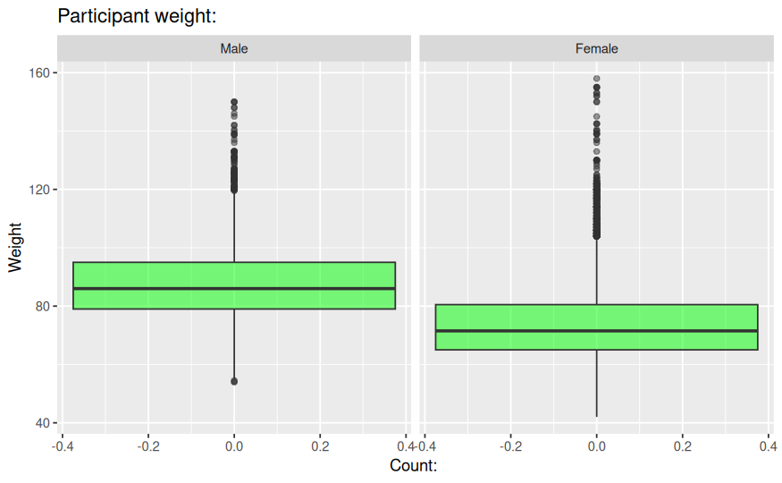

For the woman, the amount of pregnacies was visualized in the following plot:

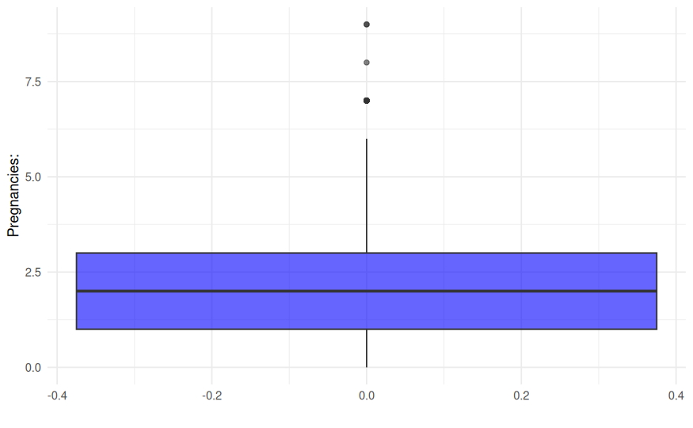

```r
ggplot(data = lifelines_df, mapping = aes(y = PREGNANCIES)) +
  geom_boxplot(fill = "blue", alpha=0.6) +
  xlab("") +
  ylab("Pregnancies:") +
  theme_minimal()
```

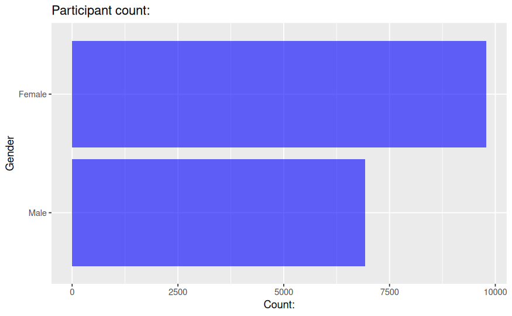

[figure not shown]

```r
FINANCE <- lifelines_df[!is.na(lifelines_df$FINANCE_T1), ]


ggplot(data = lifelines_df, mapping = aes(x = neighborhood_satisfaction, y = FINANCE_T1)) +
  geom_jitter() +
  xlab("") +
  ylab("") +
  ggtitle("Correlation between wealth and neighborhood satisfaction") +
  theme_minimal()
```

```r
NA
NA
```

### Using Generalized linear models to quantify correlations:

Here the variables used are opinion of living arragements as outcome variable and education as predictor. There appears to be a sigificant correlation between these two variables.

[figure not shown]

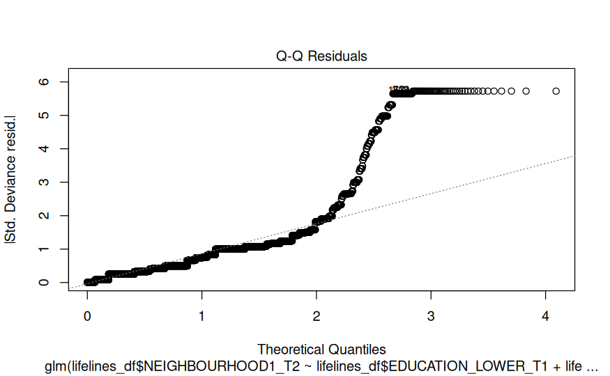

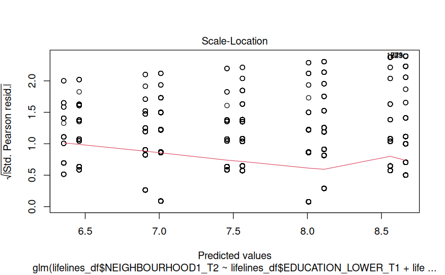

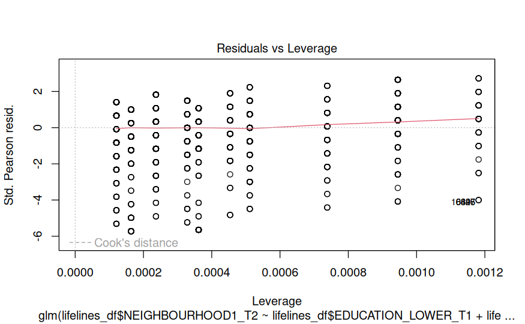

```r
summary(neighborhood_prediction)
```

```
Call:
glm(formula = lifelines_df$NEIGHBOURHOOD1_T2 ~ lifelines_df$EDUCATION_LOWER_T1 +
    lifelines_df$NEIGHBOURHOOD4_T2, na.action = na.exclude)

Coefficients:
                                Estimate Std. Error t value Pr(>|t|)
(Intercept)                      9.21457    0.02560 359.944  < 2e-16 ***
lifelines_df$EDUCATION_LOWER_T1 -0.10435    0.02803  -3.723 0.000198 ***
lifelines_df$NEIGHBOURHOOD4_T2  -0.55102    0.01193 -46.181  < 2e-16 ***
---
Signif. codes:  0 ‘***’ 0.001 ‘**’ 0.01 ‘*’ 0.05 ‘.’ 0.1 ‘ ’ 1

(Dispersion parameter for gaussian family taken to be 1.791762)

    Null deviance: 24769  on 11687  degrees of freedom
Residual deviance: 20937  on 11685  degrees of freedom
  (5008 observations deleted due to missingness)
AIC: 39991

Number of Fisher Scoring iterations: 2
```

[output not shown]

[output cut: 792 more lines]